# Practical Machine Learning

# Intro

Using devices such as Jawbone Up, Nike FuelBand, and Fitbit it is now possible to collect a large amount of data about personal activity relatively inexpensively. These type of devices are part of the quantified self movement - a group of enthusiasts who take measurements about themselves regularly to improve their health, to find patterns in their behavior, or because they are tech geeks. One thing that people regularly do is quantify how much of a particular activity they do, but they rarely quantify how well they do it. In this project, your goal will be to use data from accelerometers on the belt, forearm, arm, and dumbell of 6 participants. They were asked to perform barbell lifts correctly and incorrectly in 5 different ways. More information is available from the website here: http://groupware.les.inf.puc-rio.br/har (see the section on the Weight Lifting Exercise Dataset).

## Libraries utilized

```r
library(caret); library(rpart)
```

```r
library(rattle); library(rpart.plot)
library(randomForest); library(RColorBrewer)
library(corrplot)
```

## Load the training and test data sets

```r
training_data <- read.csv("./pml-training.csv")
testing_data <- read.csv("./pml-testing.csv")

dim(training_data);dim(testing_data)
```

```
## [1] 19622   160
```

```
## [1]  20 160
```

## Clean up training data set

This is done by removing missing values

```r
clean_train <- training_data
# pull out the "classe" field
train_classe <- as.data.frame(clean_train[, max(length(clean_train))])
colnames(train_classe) <- "classe"

# function to remove unnecessary columns
remove <- function (x) {
  remove <- grepl("^X|timestamp|window", names(x))
}

clean_train <- clean_train[,colSums(is.na(clean_train)) == FALSE]
# applying the remove function  to the new clean data set
clean_train <- clean_train[,!remove(clean_train)]
# converting columns to numeric values
clean_train <- clean_train[, sapply(clean_train, is.numeric)]
# add the "classe" values back in
clean_train <- cbind(clean_train, train_classe)
```

## Clean up testing data set by removing missing values

This is done by filtering down to complete objects

```r
clean_test <- testing_data
# pulls out the grades or "classe"
clean_test <- clean_test[, -max(length(clean_test))]
clean_test <- clean_test[, colSums(is.na(clean_test)) == 0]
# function to remove unnecessary columns

remove <- function (x) {
  remove <- grepl("^X|timestamp|window", names(x))
}
# applying the remove function
clean_test <- clean_test[,!remove(clean_test)]
#Convert columns to numeric values
clean_test <- clean_test[, sapply(clean_test, is.numeric)]
```

## Set the seed

This is so that the results can be reproduced

```r
set.seed(532)
```

## Partition training and cross validation sets

```r
inTrain <- createDataPartition(y = clean_train$classe, p = .60, list = FALSE)
```

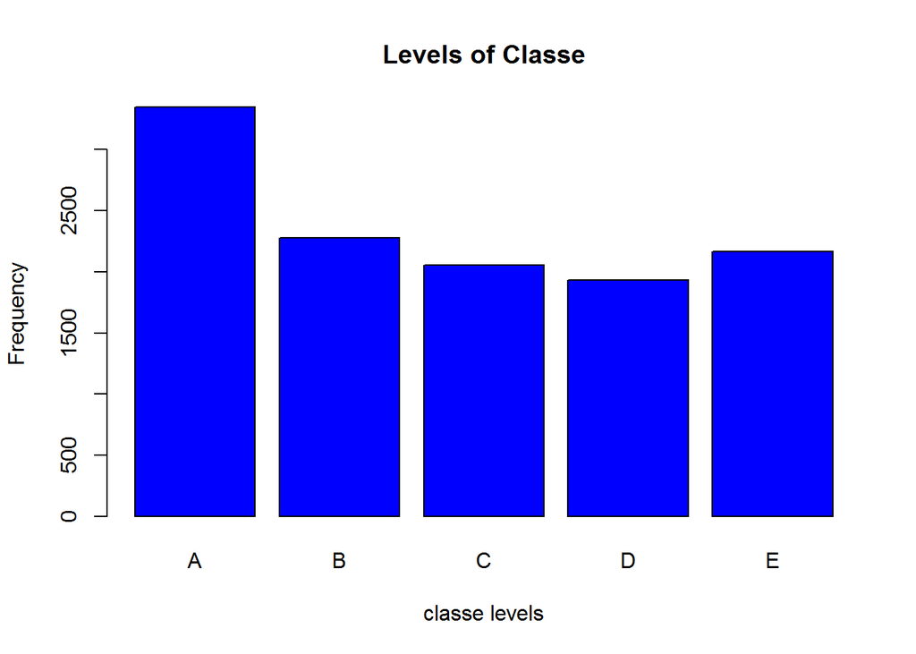

```r
clean_train <- clean_train[inTrain,]
cross_validate <- clean_train[-inTrain,]
#clean_train

plot(clean_train$classe, col="blue", main="Levels of Classe", xlab="classe levels", ylab="Frequency")
```

#Build the model RandomForest was chosen due to its ability to produce fairly strong predictions.

```r
model <- train(classe ~ ., data = clean_train, method = "rf",
               trControl = trainControl(method = "cv", 5),
               ntree = 250)
model
```

```
## Random Forest
##
## 11776 samples
##    52 predictor
##     5 classes: 'A', 'B', 'C', 'D', 'E'
##
## No pre-processing
## Resampling: Cross-Validated (5 fold)
##
## Summary of sample sizes: 9422, 9420, 9420, 9422, 9420
##
## Resampling results across tuning parameters:
##
##   mtry  Accuracy   Kappa      Accuracy SD  Kappa SD
##    2    0.9896406  0.9868934  0.001955512  0.002474386
##   27    0.9888762  0.9859281  0.001927915  0.002437790
##   52    0.9812336  0.9762555  0.003317443  0.004199199
##
## Accuracy was used to select the optimal model using  the largest value.
## The final value used for the model was mtry = 2.
```

## Predictions based on cross validated data

The model is now applied to the cross_validate data set.

```r
predict_it <- predict(model,cross_validate)

confusionMatrix(cross_validate$classe,predict_it)
```

```
## Confusion Matrix and Statistics
##
##           Reference
## Prediction    A    B    C    D    E
##          A 1325    0    0    0    0
##          B    0  924    0    0    0
##          C    0    0  825    0    0
##          D    0    0    0  769    0
##          E    0    0    0    0  866
##
## Overall Statistics
##
##                Accuracy : 1
##                  95% CI : (0.9992, 1)
##     No Information Rate : 0.2814
##     P-Value [Acc > NIR] : < 2.2e-16
##
##                   Kappa : 1
##  Mcnemar's Test P-Value : NA
##
## Statistics by Class:
##
##                      Class: A Class: B Class: C Class: D Class: E
## Sensitivity            1.0000   1.0000   1.0000   1.0000   1.0000
## Specificity            1.0000   1.0000   1.0000   1.0000   1.0000
## Pos Pred Value         1.0000   1.0000   1.0000   1.0000   1.0000
## Neg Pred Value         1.0000   1.0000   1.0000   1.0000   1.0000
## Prevalence             0.2814   0.1962   0.1752   0.1633   0.1839
## Detection Rate         0.2814   0.1962   0.1752   0.1633   0.1839
## Detection Prevalence   0.2814   0.1962   0.1752   0.1633   0.1839
## Balanced Accuracy      1.0000   1.0000   1.0000   1.0000   1.0000
```

Check the accuracy of the model

```r
model.accuracy <- postResample(predict_it, cross_validate$classe)
model.accuracy
```

```
## Accuracy    Kappa
##        1        1
```

```r
samp.error <- 1 -
  as.numeric(confusionMatrix(
    cross_validate$classe,
    predict_it)$overall[1])
samp.error
```

```
## [1] 0
```

```r
clean_test$prediction <- predict(model, clean_test)
clean_test$prediction
```

```
##  [1] B A B A A E D B A A B C B A E E A B B B
## Levels: A B C D E
```

## Decision Tree

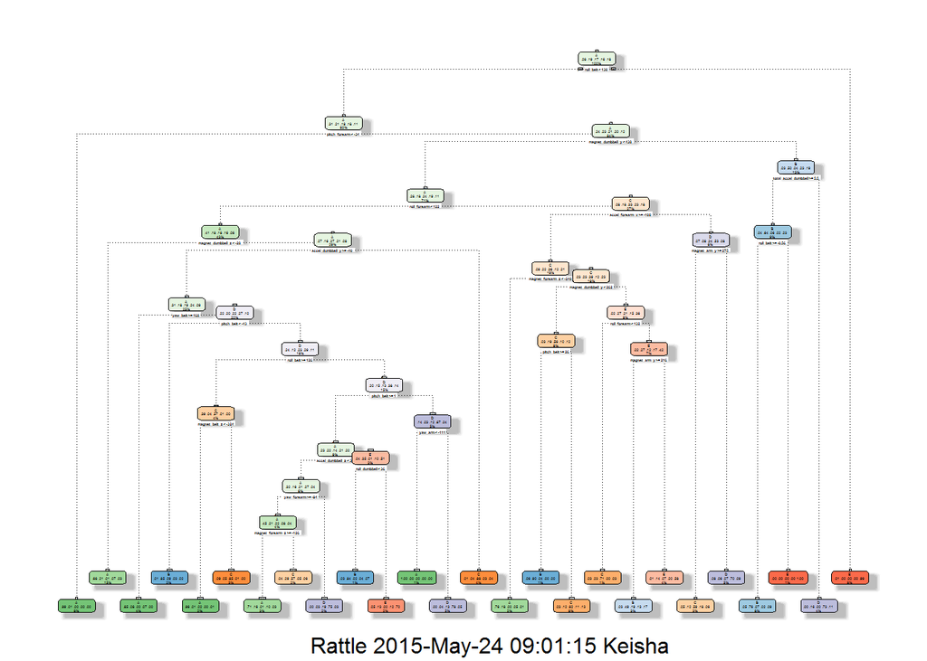

```r
tree <- rpart(classe ~ ., data = clean_train, method = "class")
fancytree <- fancyRpartPlot(tree)
```

```r
basictree <- prp(tree)
```

[figure not shown]

## Prediction output

```r
#pml_write_files = function(x){
#  n = length(x)
#  for(i in 1:n){
#    filename = paste0("problem_id_",i,".txt")
#    write.table(x[i],file=filename,quote=FALSE,row.names=FALSE,col.names=FALSE)
#  }
#}
print(clean_test$prediction)
```

```
##  [1] B A B A A E D B A A B C B A E E A B B B
## Levels: A B C D E
```

## Knitting function

```r
#library(knitr)

#build.report <- function(x) {
#  knit2html(x, "project.html")
#}
```